# histogram_data_analysis

### This notebook analyzes the orientation histograms obtained by the Fiji script (analyze_fiber_orientation.py)

The notebook is split into two parts. Both parts can be run independently.

#### Part 1: analysis of a single dataset

- Generated output:
  - Figures with multiple histograms of different slices, with different normalization options
  - Figure with average coherency per slice
  - The plots are automatically saved into the folder of the input data.

#### Part 2: combine multiple datasets and get statistics

- For each dataset the slice with the strongest horizontal resp. longitudinal fiber orientation is detected. These curves are then averaged and the standard deviation is computed.
- Generated output:
  - Figure with average+-stddev of orientation distribution of longitudinal and circular fibers.
  - Additionally an illustrative figure of chosen fiber distributions per dataset.
  - The plots are automatically saved into a user-defined folder.

#### Prerequisites:

- The Fiji script analyze_fiber_orientation.py was run on a dataset.
- For part 2: multiple datasets were analyzed.
- This notebook uses the Orientation Histogram data stored as orientationDistribution_CoherencyWeighted.csv, resp. orientationDistribution_Unweighted.csv. This data was automatically generated during fiber analysis in Fiji and should not be renamed.

#### General Jupyter Notebook Usage: The basics

- The notebook is executed cell-by-cell.
- The active/current cell is visible by being surrounded by a blue or green box.
- Green box: edit mode. Blue box: view mode. To exit the edit mode: press Esc
- To run a cell: Press Shift+Enter (runs the cell and automatically advances to the next cell)
- Auto-complete is supported (convenient when you e.g. type a folder location): start typing, then press Tab key.
- When you are completely finished: Click on Kernel->Shutdown and close all notebooks related tabs.
- If you want to do a fresh start of the analysis: click on Kernel -> Restart and Clear Output

#### Usage of this notebook:

- Start at part 1 and/or part 2.
- Run cells step-by-step.
- Some cells are titled "Adjust". Adjust the content (data folder etc.) before running them.
  - Note: if you accidentally ran it already, simply click on it, adjust the content, and run it again.

#### Good to know:

- part 2 assumes that the planarian is vertically aligned.

#### Changelog

- 2019-07-18: added part 2: combine multiple datasets
- 2019-06-11: added figure with normalized orientation distribution

===================================================================================================

### Preparations: always run this cell.

```python
import os, sys
import numpy as np
import pandas as pd
import matplotlib.pyplot as plt

%load_ext autoreload
%autoreload 2

from helpers_histogram_analysis import *
```

## Part 1: analysis of a single dataset

### This cell: Adjust

```python
# == folder where your final .csv data resides (typically "/some/path/5_orientation_analysis/data") ==
data_folder="/Users/walker/Projects/OrientationMuscleFibers_2283/enhancements/2019-07-histogram_averaging/data/EGFP_ventralsides/data_2_4/"

# == weighted or unweighted histogram (weighted=weighted by coherency). ==
# Recommended: use_weighted=True
use_weighted=True # options: True, False
```

### Automatic: Load the csv data and display a few lines

```python
fn_load=get_filename_csv_histdata(data_folder, use_weighted)

df=pd.read_csv(fn_load)
display(df.head())

# convert to numpy. remove the "sliceX" string label. first row: slice1, second rw: slice2 etc
data=(df.iloc[:,1:]).values
```

```
Found csv file with histogram data: /Users/walker/Projects/OrientationMuscleFibers_2283/enhancements/2019-07-histogram_averaging/data/EGFP_ventralsides/data_2_4/orientationDistribution_CoherencyWeighted.csv
```

|  | Label | -90 | -89 | -88 | -87 | -86 | -85 | -84 | -83 | -82 | ... | 80 | 81 | 82 | 83 | 84 | 85 | 86 | 87 | 88 | 89 |
| --- | --- | --- | --- | --- | --- | --- | --- | --- | --- | --- | --- | --- | --- | --- | --- | --- | --- | --- | --- | --- | --- |
| 0 | slice 1 | 0.000320 | 0.000337 | 0.000326 | 0.000314 | 0.000306 | 0.000272 | 0.000278 | 0.000281 | 0.000265 | ... | 0.000307 | 0.000323 | 0.000304 | 0.000330 | 0.000366 | 0.000370 | 0.000383 | 0.000374 | 0.000347 | 0.000372 |
| 1 | slice 2 | 0.000344 | 0.000325 | 0.000366 | 0.000327 | 0.000303 | 0.000303 | 0.000261 | 0.000259 | 0.000259 | ... | 0.000281 | 0.000302 | 0.000300 | 0.000364 | 0.000376 | 0.000365 | 0.000381 | 0.000369 | 0.000380 | 0.000371 |
| 2 | slice 3 | 0.000348 | 0.000348 | 0.000338 | 0.000325 | 0.000320 | 0.000298 | 0.000250 | 0.000255 | 0.000251 | ... | 0.000268 | 0.000282 | 0.000310 | 0.000341 | 0.000373 | 0.000377 | 0.000387 | 0.000368 | 0.000373 | 0.000360 |
| 3 | slice 4 | 0.000345 | 0.000332 | 0.000332 | 0.000314 | 0.000303 | 0.000283 | 0.000262 | 0.000230 | 0.000212 | ... | 0.000247 | 0.000247 | 0.000292 | 0.000332 | 0.000364 | 0.000346 | 0.000386 | 0.000371 | 0.000353 | 0.000343 |
| 4 | slice 5 | 0.000310 | 0.000302 | 0.000311 | 0.000288 | 0.000282 | 0.000266 | 0.000245 | 0.000235 | 0.000185 | ... | 0.000224 | 0.000227 | 0.000237 | 0.000281 | 0.000324 | 0.000321 | 0.000338 | 0.000332 | 0.000355 | 0.000319 |

5 rows × 181 columns

### This cell: Adjust. Specify the details of the histogram plot.

```python
# == choose slices to be plotted ==
# options: None (uses all), or a list with slice numbers (counting starts at 1), e.g. [8,10,12]
slice_selection=None
#slice_selection=[10,22,30]

# == choose color map: every string from here https://matplotlib.org/tutorials/colors/colormaps.html will work. ==
# careful: some color ranges extend to white -> invisible.
# recommended: None (will use a default), "jet", "gnuplot", "copper"
color_map=None
```

### Automatic: plots the orientation histogram and the coherency

#### un-normalized distribution

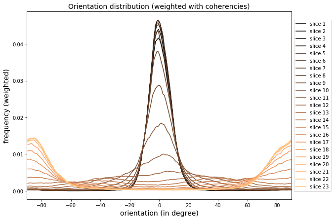

```python
plot_hist(data,slice_selection,use_weighted,False,data_folder, color_map, ylim=None)
```

#### distribution normalized to max=1 (per slice)

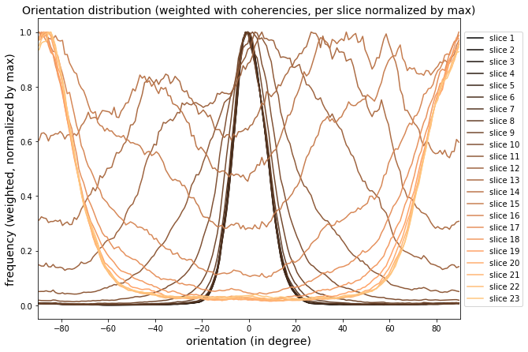

```python
plot_hist(data,slice_selection,use_weighted,True,data_folder, color_map, ylim=None)
```

#### average coherency per slice

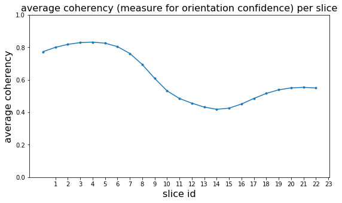

```python
plot_coherency(data,use_weighted,data_folder)
```

## Part 2: Combine multiple datasets and get statistics

### This cell: Adjust

**data_dir_list:**  
Specify a list of folders where your final .csv files reside. The folders should belong to replicates of the same experiment.  
Example (be careful with the [] and commas):

> data_dir_list=[  
> "/experiment_1/5_orientation_analysis/data",  
> "/experiment_2/5_orientation_analysis/data",  
> "/experiment_3/5_orientation_analysis/data"  
> ]

**save_dir:**  
Folder where to save the figures. Will be created if the path does not exist.

```python
data_dir_list=[
    "/Users/walker/Projects/OrientationMuscleFibers_2283/enhancements/2019-07-histogram_averaging/data/EGFP_ventralsides/data_1_1/",
    "/Users/walker/Projects/OrientationMuscleFibers_2283/enhancements/2019-07-histogram_averaging/data/EGFP_ventralsides/data_1_2/",
    "/Users/walker/Projects/OrientationMuscleFibers_2283/enhancements/2019-07-histogram_averaging/data/EGFP_ventralsides/data_2_3/",
    "/Users/walker/Projects/OrientationMuscleFibers_2283/enhancements/2019-07-histogram_averaging/data/EGFP_ventralsides/data_2_4/"
]

save_dir="/Users/walker/Projects/OrientationMuscleFibers_2283/tmp/"
```

### Automatic: Get statistics of combined datasets

#### Load all datasets and find slices with highest peak

```python
if not os.path.exists(save_dir):
    os.makedirs(save_dir)

use_weighted=True # coherency weighted

datasets,sliceids_circ,sliceids_long=load_datasets_and_find_peaks(data_dir_list,use_weighted,
       peak_circular_expected=0,peak_longitudinal_expected=90) # expected peak locations in degree, between [-90,90]
```

```
Found csv file with histogram data: /Users/walker/Projects/OrientationMuscleFibers_2283/enhancements/2019-07-histogram_averaging/data/EGFP_ventralsides/data_1_1/orientationDistribution_CoherencyWeighted.csv
Found csv file with histogram data: /Users/walker/Projects/OrientationMuscleFibers_2283/enhancements/2019-07-histogram_averaging/data/EGFP_ventralsides/data_1_2/orientationDistribution_CoherencyWeighted.csv
Found csv file with histogram data: /Users/walker/Projects/OrientationMuscleFibers_2283/enhancements/2019-07-histogram_averaging/data/EGFP_ventralsides/data_2_3/orientationDistribution_CoherencyWeighted.csv
Found csv file with histogram data: /Users/walker/Projects/OrientationMuscleFibers_2283/enhancements/2019-07-histogram_averaging/data/EGFP_ventralsides/data_2_4/orientationDistribution_CoherencyWeighted.csv
```

#### Show the selected slices

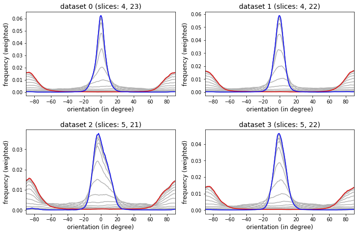

```python
titles=["dataset "+str(x) for x in range(len(data_dir_list))]
quick_plot_of_peak_selection(datasets,use_weighted,sliceids_long,sliceids_circ,titles,save_dir=save_dir,ylim=None)
```

#### Final result: Compute statistics and plot them

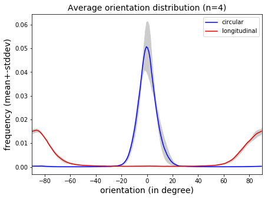

```python
ymean_circ, ystddev_circ, ymean_long, ystddev_long=get_statistics(datasets,sliceids_long,sliceids_circ)

plot_average_histogram(ymean_circ,ystddev_circ,ymean_long,ystddev_long, numsamples=len(datasets),
                       save_dir=save_dir, ylim=None) # use e.g. ylim=[0,0.07] for fixed y-range
```